# Communicating findings from the exploration of the prosper loan dataset

by Olamide Olowoniyi

# Preliminary wrangling

The prosper loan data set contains 113,937 loans with 81 variables on each loan, including loan amount, borrower rate (or interest rate), current loan status, borrower income, and so many others.

```python
#importing all necessary packages
import numpy as np
import pandas as pd
import seaborn as sb
import matplotlib.pyplot as plt
%matplotlib inline
```

```python
#loading in the dataset
loan =  pd.read_csv('prosperLoanData.csv')
loan.head()
```

|  | ListingKey | ListingNumber | ListingCreationDate | CreditGrade | Term | LoanStatus | ClosedDate | BorrowerAPR | BorrowerRate | LenderYield | ... | LP_ServiceFees | LP_CollectionFees | LP_GrossPrincipalLoss | LP_NetPrincipalLoss | LP_NonPrincipalRecoverypayments | PercentFunded | Recommendations | InvestmentFromFriendsCount | InvestmentFromFriendsAmount | Investors |
| --- | --- | --- | --- | --- | --- | --- | --- | --- | --- | --- | --- | --- | --- | --- | --- | --- | --- | --- | --- | --- | --- |
| 0 | 1021339766868145413AB3B | 193129 | 2007-08-26 19:09:29.263000000 | C | 36 | Completed | 2009-08-14 00:00:00 | 0.16516 | 0.1580 | 0.1380 | ... | -133.18 | 0.0 | 0.0 | 0.0 | 0.0 | 1.0 | 0 | 0 | 0.0 | 258 |
| 1 | 10273602499503308B223C1 | 1209647 | 2014-02-27 08:28:07.900000000 | NaN | 36 | Current | NaN | 0.12016 | 0.0920 | 0.0820 | ... | 0.00 | 0.0 | 0.0 | 0.0 | 0.0 | 1.0 | 0 | 0 | 0.0 | 1 |
| 2 | 0EE9337825851032864889A | 81716 | 2007-01-05 15:00:47.090000000 | HR | 36 | Completed | 2009-12-17 00:00:00 | 0.28269 | 0.2750 | 0.2400 | ... | -24.20 | 0.0 | 0.0 | 0.0 | 0.0 | 1.0 | 0 | 0 | 0.0 | 41 |
| 3 | 0EF5356002482715299901A | 658116 | 2012-10-22 11:02:35.010000000 | NaN | 36 | Current | NaN | 0.12528 | 0.0974 | 0.0874 | ... | -108.01 | 0.0 | 0.0 | 0.0 | 0.0 | 1.0 | 0 | 0 | 0.0 | 158 |
| 4 | 0F023589499656230C5E3E2 | 909464 | 2013-09-14 18:38:39.097000000 | NaN | 36 | Current | NaN | 0.24614 | 0.2085 | 0.1985 | ... | -60.27 | 0.0 | 0.0 | 0.0 | 0.0 | 1.0 | 0 | 0 | 0.0 | 20 |

5 rows × 81 columns

```python
#checking to see the structure of the dataset
loan.shape
```

```
(113937, 81)
```

```python
#checking the general information of the dataset
loan.info()
```

```
<class 'pandas.core.frame.DataFrame'>
RangeIndex: 113937 entries, 0 to 113936
Data columns (total 81 columns):
 #   Column                               Non-Null Count   Dtype
---  ------                               --------------   -----
 0   ListingKey                           113937 non-null  object
 1   ListingNumber                        113937 non-null  int64
 2   ListingCreationDate                  113937 non-null  object
 3   CreditGrade                          28953 non-null   object
 4   Term                                 113937 non-null  int64
 5   LoanStatus                           113937 non-null  object
 6   ClosedDate                           55089 non-null   object
 7   BorrowerAPR                          113912 non-null  float64
 8   BorrowerRate                         113937 non-null  float64
 9   LenderYield                          113937 non-null  float64
```

[output cut: 73 more lines]

# What is the structure of the dataset?

From the quick assessment of the data done above, the results showed that the dataset contained 81 columns and 113,937 rows, that is, 113,937 loans with 81 variables on each loan.

# What is/are the main feature(s) of interest in this dataset?

I am majorly interested in the factors or variables that determine a loan's interest rate.

# What features in the dataset will help support investigation into the feature(s) of interest?

I suspect that there are a couple of features in the dataset responsible for deteminining a loan's interest rate. These include: The Borrower's APR, Prosperscore, Creditscore and DebtToIncomeRatio.

# Univariate exploration

I started this section by creating a new dataframe with columns of interest and named it-loan_target.

```python
#selecting only columnns of interest to create a new df
cols = ['Term', 'ListingCreationDate', 'LoanStatus', 'ProsperScore', 'MonthlyLoanPayment', 'BorrowerState', 'LoanOriginalAmount', 'ListingCategory (numeric)', 'BorrowerRate', 'BorrowerAPR', 'StatedMonthlyIncome', 'CreditScoreRangeLower',
        'CreditScoreRangeUpper', 'Occupation', 'AvailableBankcardCredit', 'EmploymentStatus', 'RevolvingCreditBalance', 'DebtToIncomeRatio']
loan_target = loan[cols]
```

```python
#checking to see if the above operation was successful
loan_target.head()
```

|  | Term | ListingCreationDate | LoanStatus | ProsperScore | MonthlyLoanPayment | BorrowerState | LoanOriginalAmount | ListingCategory (numeric) | BorrowerRate | BorrowerAPR | StatedMonthlyIncome | CreditScoreRangeLower | CreditScoreRangeUpper | Occupation | AvailableBankcardCredit | EmploymentStatus | RevolvingCreditBalance | DebtToIncomeRatio |
| --- | --- | --- | --- | --- | --- | --- | --- | --- | --- | --- | --- | --- | --- | --- | --- | --- | --- | --- |
| 0 | 36 | 2007-08-26 19:09:29.263000000 | Completed | NaN | 330.43 | CO | 9425 | 0 | 0.1580 | 0.16516 | 3083.333333 | 640.0 | 659.0 | Other | 1500.0 | Self-employed | 0.0 | 0.17 |
| 1 | 36 | 2014-02-27 08:28:07.900000000 | Current | 7.0 | 318.93 | CO | 10000 | 2 | 0.0920 | 0.12016 | 6125.000000 | 680.0 | 699.0 | Professional | 10266.0 | Employed | 3989.0 | 0.18 |
| 2 | 36 | 2007-01-05 15:00:47.090000000 | Completed | NaN | 123.32 | GA | 3001 | 0 | 0.2750 | 0.28269 | 2083.333333 | 480.0 | 499.0 | Other | NaN | Not available | NaN | 0.06 |
| 3 | 36 | 2012-10-22 11:02:35.010000000 | Current | 9.0 | 321.45 | GA | 10000 | 16 | 0.0974 | 0.12528 | 2875.000000 | 800.0 | 819.0 | Skilled Labor | 30754.0 | Employed | 1444.0 | 0.15 |
| 4 | 36 | 2013-09-14 18:38:39.097000000 | Current | 4.0 | 563.97 | MN | 15000 | 2 | 0.2085 | 0.24614 | 9583.333333 | 680.0 | 699.0 | Executive | 695.0 | Employed | 6193.0 | 0.26 |

```python
#checking general info of the new df
loan_target.info()
```

```
<class 'pandas.core.frame.DataFrame'>
RangeIndex: 113937 entries, 0 to 113936
Data columns (total 18 columns):
 #   Column                     Non-Null Count   Dtype
---  ------                     --------------   -----
 0   Term                       113937 non-null  int64
 1   ListingCreationDate        113937 non-null  object
 2   LoanStatus                 113937 non-null  object
 3   ProsperScore               84853 non-null   float64
 4   MonthlyLoanPayment         113937 non-null  float64
 5   BorrowerState              108422 non-null  object
 6   LoanOriginalAmount         113937 non-null  int64
 7   ListingCategory (numeric)  113937 non-null  int64
 8   BorrowerRate               113937 non-null  float64
 9   BorrowerAPR                113912 non-null  float64
 10  StatedMonthlyIncome        113937 non-null  float64
 11  CreditScoreRangeLower      113346 non-null  float64
 12  CreditScoreRangeUpper      113346 non-null  float64
 13  Occupation                 110349 non-null  object
 14  AvailableBankcardCredit    106393 non-null  float64
 15  EmploymentStatus           111682 non-null  object
 16  RevolvingCreditBalance     106333 non-null  float64
 17  DebtToIncomeRatio          105383 non-null  float64
dtypes: float64(10), int64(3), object(5)
memory usage: 15.6+ MB
```

I will start this section investigating the distribution of credit scores among borrowers. Credit score is believed to be an imporant factor in determining whether a borrower is loan worthy or not.

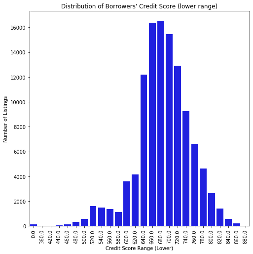

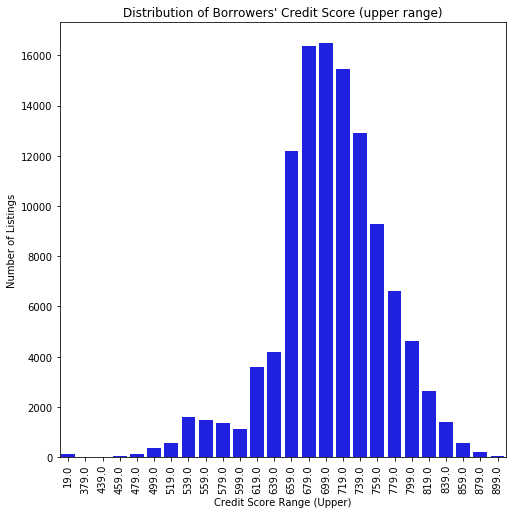

```python
#plotting histogram to check the distribution of credit scores of borrowers
plt.figure(figsize=(8,8))
sb.countplot(data = loan_target, x = 'CreditScoreRangeLower', color = 'blue')
plt.title("Distribution of Borrowers' Credit Score (lower range)")
plt.xlabel('Credit Score Range (Lower)')
plt.ylabel('Number of Listings')
plt.xticks(rotation=90);

plt.figure(figsize=(8,8))
sb.countplot(data = loan_target, x = 'CreditScoreRangeUpper', color = 'blue')
plt.title("Distribution of Borrowers' Credit Score (upper range)")
plt.xlabel('Credit Score Range (Upper)')
plt.ylabel('Number of Listings')
plt.xticks(rotation=90);
```

The upper and lower range plots look similar and they both look like a normally distributed data. From the plots, a lot of the borrowers are having credit scores between 600 and 800. The mode of the distribution of the lower range falls around 680 while the upper range falls around 699. While different lenders have different ideas of what they consider acceptable credit score, generally a good credit score is betweet 670 and 639. this is where a considerable number of our borrowers lie.

I will be checking distribution of the properscore next

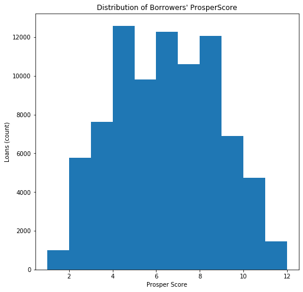

```python
#plotting histogram to check the distribution of ptoprscore
bins = np.arange(1, 13, 1)
plt.figure(figsize=(8, 8))
plt.hist(data = loan_target, x = 'ProsperScore', bins=bins);
plt.title("Distribution of Borrowers' ProsperScore");
plt.xlabel('Prosper Score')
plt.ylabel('Loans (count)');
```

This result does not tally with the credit score result. From the prosper loan dictionary, a score of 4 which is our mode here is quite weak. This information here is telling us that most of loans given out were considered high risk.

I will check the debt to income ratio next

```python
#extracting descriptive stat to determine appropriate bins
loan_target['DebtToIncomeRatio'].describe()
```

```
count    105383.000000
mean          0.275947
std           0.551759
min           0.000000
25%           0.140000
50%           0.220000
75%           0.320000
max          10.010000
Name: DebtToIncomeRatio, dtype: float64
```

```python
#removing outliers
loan_target = loan_target[loan_target.DebtToIncomeRatio < 1]
```

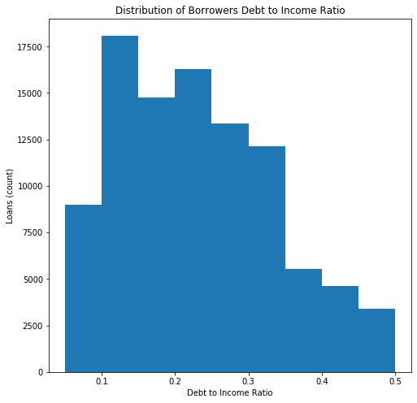

```python
#plotting histogram
bins = np.arange(0.05, 0.55, 0.05)
plt.figure(figsize=(8, 8))
plt.hist(data = loan_target, x = 'DebtToIncomeRatio', bins=bins)
plt.title('Distribution of Borrowers Debt to Income Ratio')
plt.xlabel('Debt to Income Ratio')
plt.ylabel('Loans (count)');
```

I will check the distribution of revolving credit balance next

```python
#extracting descriptive stat to determine appropriate bins
loan_target.RevolvingCreditBalance.describe()
```

```
count    9.721800e+04
mean     1.728328e+04
std      3.194500e+04
min      0.000000e+00
25%      3.164000e+03
50%      8.556000e+03
75%      1.930800e+04
max      1.435667e+06
Name: RevolvingCreditBalance, dtype: float64
```

```python
loan_target['RevolvingCreditBalance'].quantile([0, 0.1, 0.2, 0.3, 0.4, 0.5, 0.6, 0.7, 0.8, 0.9, 0.95, 0.97, 1])
```

```
0.00          0.00
0.10        670.00
0.20       2201.00
0.30       4108.00
0.40       6094.00
0.50       8556.00
0.60      11717.00
0.70      16231.00
0.80      23491.60
0.90      39069.60
0.95      59261.30
0.97      80500.84
1.00    1435667.00
Name: RevolvingCreditBalance, dtype: float64
```

```python
#cutting of values above 90000, since 97% of the data is less than that
loan_target = loan_target[loan_target.RevolvingCreditBalance < 90000]
```

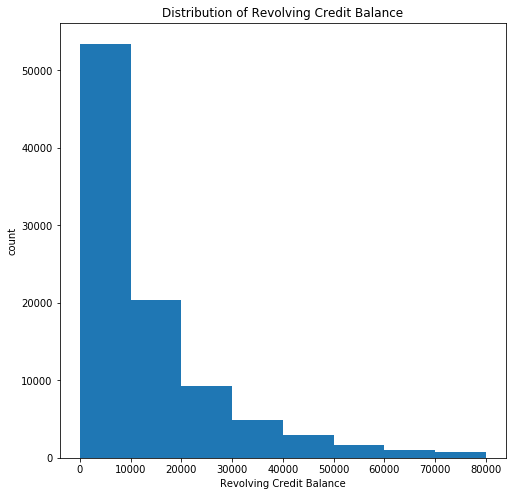

```python
#plotting histogram
bins = np.arange(0, 90000, 10000)
plt.figure(figsize=(8, 8))
plt.hist(data = loan_target, x = 'RevolvingCreditBalance', bins=bins)
plt.title('Distribution of Revolving Credit Balance')
plt.xlabel('Revolving Credit Balance')
plt.ylabel('count');
```

Next, I am interested in knowing what the borrower's monthly income is

```python
#extracting the descriptive stat in order to determine the bins for the histogram
loan_target['StatedMonthlyIncome'].describe()
```

```
count     94794.000000
mean       5597.120888
std        4649.874884
min           0.000000
25%        3333.333333
50%        4791.666667
75%        6833.333333
max      483333.333333
Name: StatedMonthlyIncome, dtype: float64
```

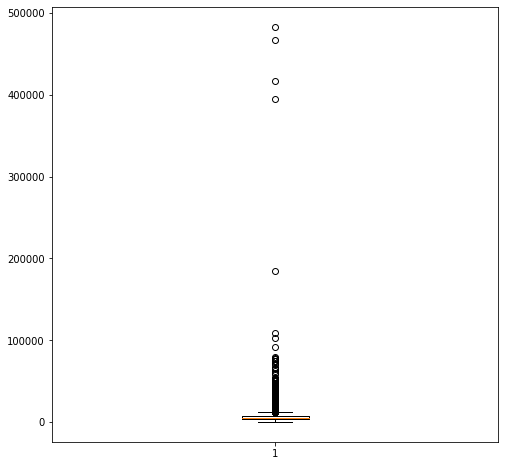

```python
#plotting a boxplot to find outliers
plt.figure(figsize=(8, 8))
plt.boxplot(loan_target.StatedMonthlyIncome);
```

There are outliers in this dataset and to standardise my analysis, I have chosen to not include them in my analysis. Threfore, I will cap the monthly income at 20,000 per month

```python
loan_target = loan_target[loan_target.StatedMonthlyIncome < 20000]
```

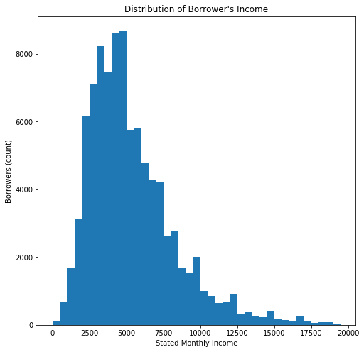

```python
bins = np.arange(1, 20000, 500)
plt.figure(figsize=(8, 8))
plt.hist(data = loan_target, x = 'StatedMonthlyIncome',bins=bins)
plt.title("Distribution of Borrower's Income")
plt.xlabel('Stated Monthly Income')
plt.ylabel('Borrowers (count)');
```

The histogram is again a right skewed distribution with most of the borrowers' monthly income around 5,000.

The next individual variable I will explore is the monthly loan payment.

```python
#extracting descriptive stat to determine appropriate bins
loan_target['MonthlyLoanPayment'].describe()
```

```
count    94052.000000
mean       276.905049
std        189.265639
min          0.000000
25%        137.660000
50%        228.355000
75%        375.210000
max       2251.510000
Name: MonthlyLoanPayment, dtype: float64
```

```python
#removing outliers
loan_target['MonthlyLoanPayment'].quantile([0, 0.1, 0.2, 0.3, 0.4, 0.5, 0.6, 0.7, 0.8, 0.9, .97, 1])
```

```
0.00       0.000
0.10      83.910
0.20     123.122
0.30     157.580
0.40     174.200
0.50     228.355
0.60     285.740
0.70     345.070
0.80     408.200
0.90     537.030
0.97     710.970
1.00    2251.510
Name: MonthlyLoanPayment, dtype: float64
```

```python
#cutting off values greater than 700 since 97% of the dataset is within that range
loan_target = loan_target[loan_target.MonthlyLoanPayment < 700]
```

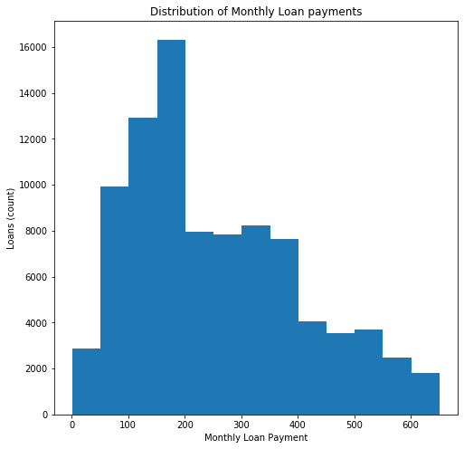

```python
#plotting a histogram
bins = np.arange(1, 700, 50)
plt.figure(figsize=(8, 8))
plt.hist(data = loan_target, x = 'MonthlyLoanPayment', bins=bins);
plt.title('Distribution of Monthly Loan payments')
plt.xlabel('Monthly Loan Payment')
plt.ylabel('Loans (count)');
```

The result shows that most of the monthly loan payments are less than 400, with the mode of the distribution around 200. in comparison, with income levels previously explored, we can say that the borrowers repaying their loans should not be too much problem.

Next, let's check the terms of these loans

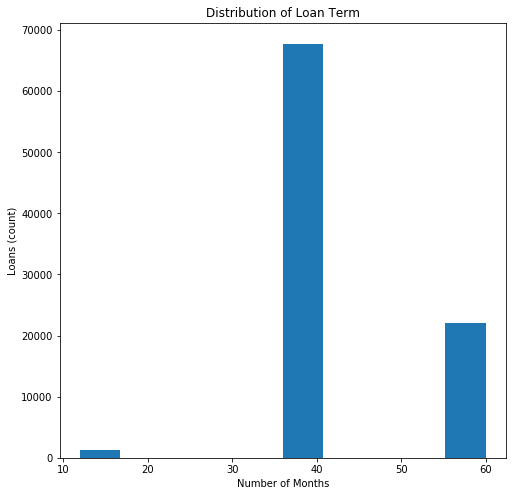

```python
plt.figure(figsize=(8, 8))
plt.hist(data = loan_target, x = 'Term');
plt.title('Distribution of Loan Term')
plt.xlabel('Number of Months')
plt.ylabel('Loans (count)');
```

From the histogram, we can see that the loans are given in 12, 36 and 60 month terms. However, most of the borrowers are clearly choosing the 36 month term.

Next, I'll like to see the BorrowerAPR

```python
#check the descriptive stat to determine the appropriate bins
loan_target['BorrowerAPR'].describe()
```

```
count    91104.000000
mean         0.219262
std          0.080450
min          0.006530
25%          0.156510
50%          0.210250
75%          0.283860
max          0.423950
Name: BorrowerAPR, dtype: float64
```

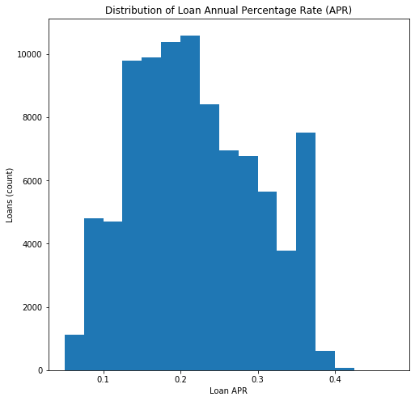

```python
#plotting histogram
bins = np.arange(0.05, 0.50, 0.025)
plt.figure(figsize=(8, 8))
plt.hist(data = loan_target, x = 'BorrowerAPR', bins=bins)
plt.title('Distribution of Loan Annual Percentage Rate (APR)')
plt.xlabel('Loan APR')
plt.ylabel('Loans (count)');
```

This distribution appears to be normally distributed with large spikes around the extremeties. The mode of the distribution is around 0.2.

Another interesting cariable to examine is the employment status

```python
#converting data type to categorical
emp_order = ['Employed','Self-employed','Full-time','Part-time','Retired','Other','Not employed', 'Not available']
ordered_var = pd.api.types.CategoricalDtype(ordered = True,
                                    categories = emp_order)
loan_target['EmploymentStatus'] = loan_target['EmploymentStatus'].astype(ordered_var)
```

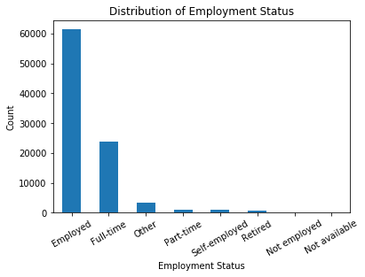

```python
#plotting bar chart
loan_target['EmploymentStatus'].value_counts().plot(kind='bar')
plt.title('Distribution of Employment Status')
plt.xlabel('Employment Status')
plt.ylabel('Count')
plt.figsize=(8,8)
plt.xticks(rotation=30);
```

Next, I want to check for the occupation of the borrowers?

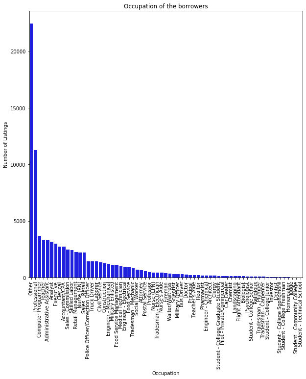

```python
plt.figure(figsize=(10,10))
cat_order = loan_target['Occupation'].value_counts().index
sb.countplot(data = loan_target, x = 'Occupation', color = 'blue', order = cat_order)
plt.title('Occupation of the borrowers')
plt.xlabel('Occupation')
plt.ylabel('Number of Listings')
plt.xticks(rotation=90);
```

This chart is a bit too cumbersome and not a lot of information can be extracted from it, so I will go ahead to extract the top 10 occupation.

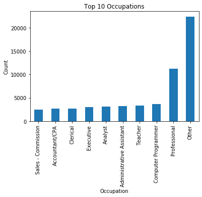

```python
#plotting bar chart of the  top ten occupation
loan_target['Occupation'].value_counts()[9::-1].plot(kind='bar')
plt.title('Top 10 Occupations')
plt.xlabel('Occupation')
plt.ylabel('Count')
plt.figsize=(8,8)
```

This chart was not very useful as most of the borrowers indicated their occuoaction as 'other' and 'professional'. This impacted the accuracy of the distribution.

Lastly, it would be interesting to check why thr borrowers collected loans (listing categories).

```python
# Renaming the column to Listing Category and changing the datatype
loan_target.rename(columns={'ListingCategory (numeric)': 'ListingCategory'}, inplace=True)
loan_target['ListingCategory'] = loan_target['ListingCategory'].astype('str')
```

```python
#converting the data type to categorical
cat_names = {'0': 'Not Available', '1': 'Debt Consolidation', '2': 'Home Improvement', '3': 'Business', '4': 'Personal Loan', '5': 'Student Use', '6': 'Auto', '7': 'Other', '8': 'Baby&Adoption', '9': 'Boat', '10': 'Cosmetic Procedure', '11': 'Engagement Ring', '12': 'Green Loans', '13': 'Household Expenses', '14': 'Large Purchases', '15': 'Medical/Dental', '16': 'Motorcycle', '17': 'RV', '18': 'Taxes', '19': 'Vacation', '20': 'Wedding Loans'}
loan_target['ListingCategory'].replace(cat_names, inplace=True)
loan_target['ListingCategory'] = loan_target['ListingCategory'].astype('category')
```

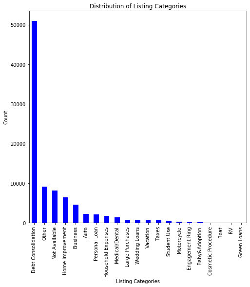

```python
#PLotting bar chart
plt.figure(figsize=(8, 8))
pd.value_counts(loan_target['ListingCategory']).plot.bar(color='blue');
plt.title('Distribution of Listing Categories');
plt.xlabel('Listing Categories')
plt.ylabel('Count');
```

This bar chart is quite interesting with debt consolidation being in the lead of the listing categories. It appears most of the borrowers are taking out loans to pay off other debts even though a couple of other variables explored befored places the borrowers in fairly good financial situation. Following closely, are 'other' and 'NA' which are not very usueful values.

Discuss the distribution(s) of your variable(s) of interest. Were there any unusual points? Did you need to perform any transformations?

My unvariate exploration provided a good first insight into the prosper loan data sight. Howefver, I found that some of my variables of interest do not necessariily agree with each other. the data showed that the ethe borrowers had fairly good credit scores, their debt to income ratio was also good, their stated monthly income levels and monthly loan payments were such that they should be able to pay without too much stress, evein their revolvong credit balance seemed good. However, the the borrower's APR and prosper scores seemed to tell a different stories implying that the borrowers were taking out high riisk loans or my be in some kind of financial trouble. Even the listing categories semmed to agree with this as most of the loans the borrowers took out fell under the debt conolidation catergory i.e. to pay off other debts.

Of the features you investigated, were there any unusual distributions? Did you perform any operations on the data to tidy, adjust, or change the form of the data? If so, why did you do this?

# Bivariate Exploration

This section of the analysis will be used to investigate relationships between pairs of variable of interest to get better insights.

First, I will begin with a correlation matrix to find out if any variables are highly correlated

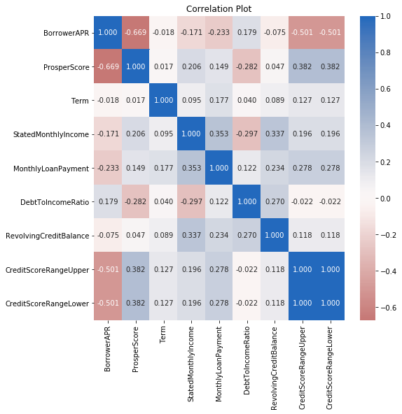

```python
num_vars = ['BorrowerAPR', 'ProsperScore',  'Term', 'StatedMonthlyIncome', 'MonthlyLoanPayment', 'DebtToIncomeRatio',
            'RevolvingCreditBalance', 'CreditScoreRangeUpper', 'CreditScoreRangeLower',]

plt.figure(figsize = [8, 8])
sb.heatmap(loan_target[num_vars].corr(), annot = True, fmt = '.3f',
           cmap = 'vlag_r', center = 0)
plt.title('Correlation Plot')
plt.show()
```

I do not see a clear positive relationship between any pairs. It can be assumed that the relationship between BorrowerAPR and ProsperScore are negatively correlated because borrowers with lower scores are more likely to pay higher APR.

let's take a futher look at the relationship between the borrower APR and the prosper score next

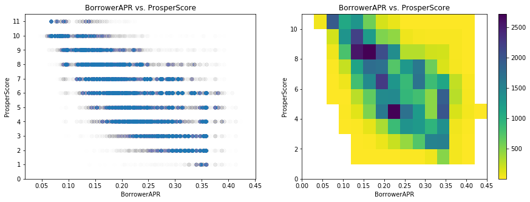

```python
#plotting scatter plot and heat map plot
plt.figure(figsize = [15, 5])

plt.subplot(1, 2, 1)
plt.scatter(data = loan_target, x = 'BorrowerAPR', y = 'ProsperScore', alpha =  0.005)
plt.yticks(np.arange(0, 12, 1))
plt.title('BorrowerAPR vs. ProsperScore')
plt.xlabel('BorrowerAPR')
plt.ylabel('ProsperScore')


plt.subplot(1, 2, 2)
bins_x = np.arange(0, loan_target['BorrowerAPR'].max()+0.05, 0.03)
bins_y = np.arange(0, loan_target['ProsperScore'].max()+1, 1)
plt.hist2d(data = loan_target, x = 'BorrowerAPR', y = 'ProsperScore', bins = [bins_x, bins_y],
               cmap = 'viridis_r', cmin = 0.5)
plt.colorbar()
plt.title('BorrowerAPR vs. ProsperScore')
plt.xlabel('BorrowerAPR')
plt.ylabel('ProsperScore');
```

From here, we can see that the higher the rating, the lower the APR which is plausible as borrowers with higher ratings are believed to be more loanworthy. I wnat to see this relationship a bit more clearly; so I will use a box plot to show it again

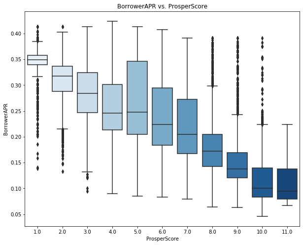

```python
sb.boxplot(data = loan_target, x = 'ProsperScore', y = 'BorrowerAPR', palette='Blues')
plt.gcf().set_size_inches(10, 8)
plt.title('BorrowerAPR vs. ProsperScore')
plt.xlabel('ProsperScore')
plt.ylabel('BorrowerAPR');
```

Very clearly, we can see that prosper score is a strong determining factor for the interest rate. As the prosper score increases, the interest rate decreases.

Next, let's see if tthere will be a similar relationship with the credit score vs borrower APR

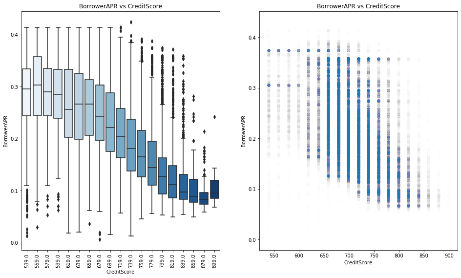

```python
#plotting boxplot and scatter plot to show the relationship between credit score and Borrower APR
plt.subplot(1, 2, 1)
ax = sb.boxplot(data = loan_target, x = 'CreditScoreRangeUpper', y = 'BorrowerAPR', palette="Blues")
plt.gcf().set_size_inches(16, 9)
plt.title('BorrowerAPR vs CreditScore');
plt.xlabel('CreditScore')
plt.ylabel('BorrowerAPR');
ax.set_xticklabels([t.get_text()  for t in ax.get_xticklabels()],rotation=90)



plt.subplot(1, 2, 2)
plt.gcf().set_size_inches(16, 9)
plt.scatter('CreditScoreRangeUpper', 'BorrowerAPR', data=loan_target, alpha = 0.003);
plt.title('BorrowerAPR vs CreditScore');
plt.xlabel('CreditScore')
plt.ylabel('BorrowerAPR');
```

One other relationship I'll like to establish is the one between the Borrower APR and their monthly incomes

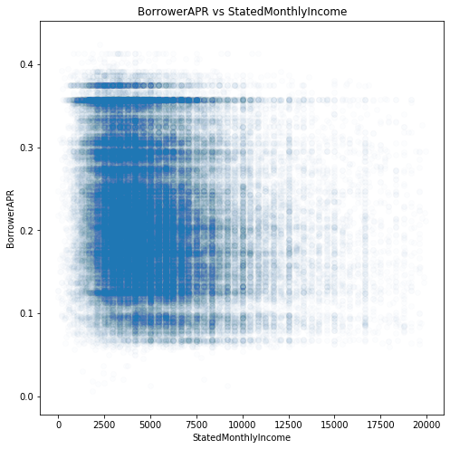

```python
#plotting a scatterplot to establish the relationship between BorrowerAPR and Statedmonthlyincome
plt.figure(figsize = [8,8])
plt.scatter('StatedMonthlyIncome', 'BorrowerAPR', data=loan_target, alpha = 0.01);
plt.title('BorrowerAPR vs StatedMonthlyIncome');
plt.xlabel('StatedMonthlyIncome')
plt.ylabel('BorrowerAPR');
```

This scatterplot does not really offer any useful information, except the already known fact that most of the borrower's income level is around 5000

Next, I will take a closer look at the relationship between BorrowerAPR and monthlyloanpayments

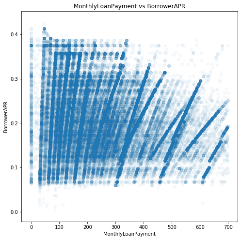

```python
#use scatter to further investigate MonthlyLoanPayment vs BorrowerAR
plt.figure(figsize = [8,8])
plt.scatter('MonthlyLoanPayment', y='BorrowerAPR', data = loan_target, alpha = 0.03);
plt.title('MonthlyLoanPayment vs BorrowerAPR');
plt.xlabel('MonthlyLoanPayment')
plt.ylabel('BorrowerAPR');
```

With points scattered across the plot, this does not really provide any useful information but we can see that most of the loan payments were less than 500 as observed earlier.

Next, I will take a closer look at the relationship between statedmonthlyincome and monthlyloanpayments

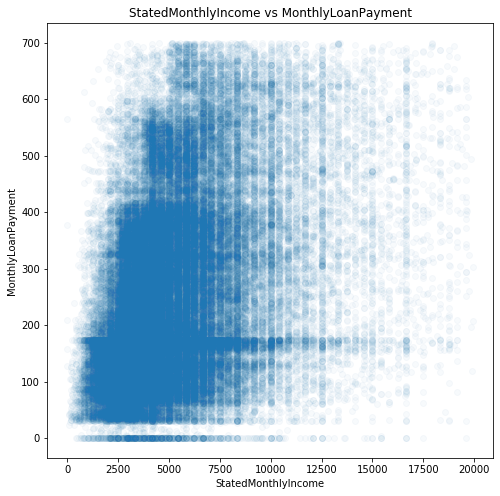

```python
plt.figure(figsize = [8,8])
plt.scatter('StatedMonthlyIncome', y='MonthlyLoanPayment', data = loan_target, alpha = 0.03);
plt.title('StatedMonthlyIncome vs MonthlyLoanPayment');
plt.xlabel('StatedMonthlyIncome')
plt.ylabel('MonthlyLoanPayment');
```

in this graph, there is a slight correlation between the income level and monthly payment, as the income rises, the borrower's monthly payment rises proportionately. Next, I will check the relationship between monthy income of the borrowers and ther DTI

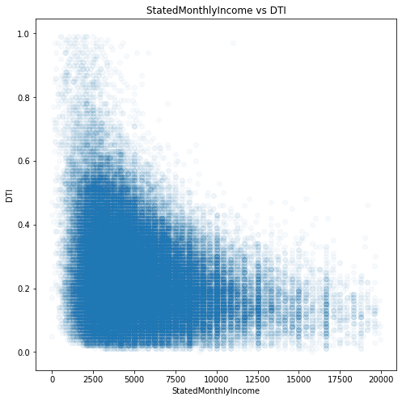

```python
plt.figure(figsize = [8,8])
plt.scatter('StatedMonthlyIncome', y='DebtToIncomeRatio', data = loan_target, alpha = 0.03);
plt.title('StatedMonthlyIncome vs DTI');
plt.xlabel('StatedMonthlyIncome')
plt.ylabel('DTI');
```

In this graph, there is a clear correlation between the monthly income and DTI of the borrowers, as the lesser the income level, higher the DTI, implying that people with low income levels take on more loans. Next, I will look more closely at relationship between monthly income and revolving credit balance

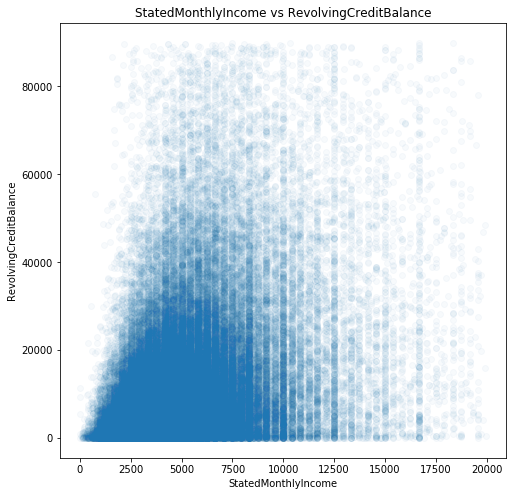

```python
plt.figure(figsize = [8,8])
plt.scatter('StatedMonthlyIncome', y='RevolvingCreditBalance', data = loan_target, alpha = 0.03);
plt.title('StatedMonthlyIncome vs RevolvingCreditBalance');
plt.xlabel('StatedMonthlyIncome')
plt.ylabel('RevolvingCreditBalance');
```

Finally, I will like to take a closer look at BorrowerAPR and Employment Status

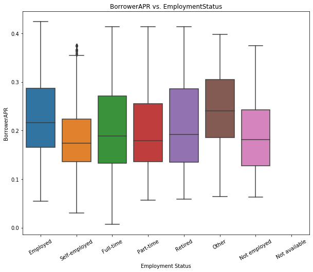

```python
#plotting a bloxplot to investigate relationship between employment status and borrower APR
plt.figure(figsize = [8, 8])

sb.boxplot(data = loan_target, x = 'EmploymentStatus', y = 'BorrowerAPR')
plt.gcf().set_size_inches(10, 8)
plt.title('BorrowerAPR vs. EmploymentStatus')
plt.xlabel('Employment Status')
plt.ylabel('BorrowerAPR')
plt.xticks(rotation=30);
```

There is very little correlation here between the borrower's employment status and their loan apr. one would expect an employed person to be given better loan inteest that an unemployed. This graph says otherwise. It does not look like employment status has an impact on the BorrowerAPR

Talk about some of the relationships you observed in this part of the investigation. How did the feature(s) of interest vary with other features in the dataset?

1. I observed that Prosper Score and Borrower APR have a strong correlation, where the higher the prosper score, the lower the APR. This was not surprising at all, as prosper score is an independent variable designed as a custom risk score using historical Data.
2. Similarly, there was also a strong correlation between the credit scores of borrowers and the APR. This is expected, as generally people with good credit scores are deemed reliable and loan worthy.
3. I also observed a slight correlation between the stated monthly income and the monthly loan payment, where the higher the income level, the higher the loan payments.
4. The correlation between stated monthly income and Debt to income ratio was a lot clearer, here, the lessser the income level, the higher the debt to income ratio; implying that people with lowr incomes take on more loans or have more debts to pay.

Did you observe any interesting relationships between the other features (not the main feature(s) of interest?

I observed that there was very little correlation between the loan APR and the borrower's employment status. Here, you have borrower's that are unemployed having lower APR on their loans than an employed person. I found this really strange and rather interesting. What could have driven that decision?

# Multivariate Exploration

For this section, I will combine all three of my key variables of interest and explore them together

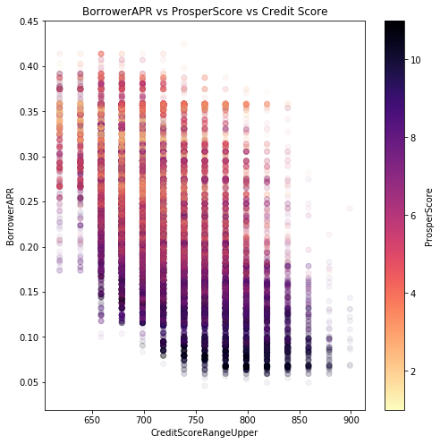

```python
#plotting a scatterplot to investigate relationship among CreditScore,BorrowerAPR and ProsperScore
plt.figure(figsize = [8,8])
plt.scatter(data=loan_target, x='CreditScoreRangeUpper', y='BorrowerAPR', c='ProsperScore', cmap='magma_r', alpha=0.05);
cbar = plt.colorbar(label='ProsperScore')
cbar.solids.set(alpha=1)
plt.title('BorrowerAPR vs ProsperScore vs Credit Score');
plt.xlabel('CreditScoreRangeUpper')
plt.ylabel('BorrowerAPR');
```

This scatterplot shows the borrowers prosper score >10 have the best APRs-which are typically less that 10% (0.1). Here we can see that the best APRs (Below 0.1) are mostly borrowers with a Prosperscore above 10 and above 700. However, there are some borrowers with credit scores below 700, that have great prosper scores, but very few.

[figure not shown]

```python
plt.subplot(1, 2, 1)
plt.gcf().set_size_inches(20, 10)
plt.subplots_adjust(wspace=0.3)
plt.scatter(data=loan_target, x='Term', y='BorrowerAPR', c='CreditScoreRangeUpper', cmap='viridis_r', alpha=0.2);
cbar = plt.colorbar(label='Term')
cbar.solids.set(alpha=1)
plt.title('BorrowerAPR vs CreditScore vs Term');
plt.xlabel('CreditScoreRangeUpper')
plt.ylabel('BorrowerAPR');
plt.yticks(np.arange(0, 0.5, step=0.05));

plt.subplot(1, 2, 2)
plt.gcf().set_size_inches(20, 10)
plt.subplots_adjust(wspace=0.2)
plt.scatter(data=loan_target, x='Term', y='BorrowerAPR', c='ProsperScore', cmap='viridis_r', alpha=0.2);
cbar = plt.colorbar(label='Term')
cbar.solids.set(alpha=1)
plt.title('BorrowerAPR vs ProsperScore vs Term');
plt.xlabel('ProsperScore')
plt.ylabel('BorrowerAPR');
plt.yticks(np.arange(0, 0.5, step=0.05));
```

From the loan terms earlier analysed during our unvariate exploration, we know that prosper loans are given in 12, 36 and 60 terms. from this plot, we can see that the credit score plot comes out as expected, as the rates are increasing, we see lower credit scores. However, At the 36 term loans, more yellow dots can be observed there than any of the remaining two terms. This could imply that there are more borrowers with really low creditscores taking out 36 term loans.

The ProsperScore plot on the other hand is almost similar to to the credit score plot in distribution, as we can see that higher prosper scores got lower rates. Similarly, there are more borrowers going for the 36 months loan and there more yellow dots around this point indicating that a lot of weak prosper scores among borrowers taking out the 36 month term loans.

Talk about some of the relationships you observed in this part of the investigation. Were there features that strengthened each other in terms of looking at your feature(s) of interest?

I decided to combine the Credit Score, Prosper score and BorrowerAPR because these values showed the strongest correlation with one another. The plot showed that credit score was a big factor in in determining a loan's APR and it also showed that it is possible for with credit scores around 700 to have have great prosper scores like 10. This grants borrowers with these scores access to loans with even lower interest rates which may not have been possible if they were considered solely on their credit scores.

Plotting these three variables together stregthened the analysis for me to see this insight in this way.

Were there any interesting or surprising interactions between features?

Of course, the addition of the loan terms to the exploration provided even more insight. We could see that there are more borrowers with lower credit scores opting for the 36 month loans. Same thing applies for the prosper loan data, with more borrowers opting for the 36 term loans and these borrowers were observed to have lower prosper scores credit scores than the other borrowers.